# Fit GLMMs

Ihsan

29/04/2021

Load libraries

```r
library("readxl")
library("tidyverse")
library("dplyr")
library("SDMTools")
library("glmmTMB")
library("DHARMa")
library("here")
library("gridExtra")
```

### Import data

```r
dat <- read_excel("lesion_weather_data.xlsx", sheet = 1, na= "NA") %>%
  group_by(rainfall_event) %>%
  mutate(wind_direction=circular.averaging(wind_direction)) %>%
  mutate(rainfall_event = as.factor(rainfall_event)) %>%
  mutate(total_lesions = as.integer(total_lesions))
```

Use `set.seed()` for reproducibility purposes

```r
set.seed(42)
```

### Model_1 (All variables)

Include all variables with rainfall event as a random effect

```r
mod1 <-
  glmmTMB(
    total_lesions ~  total_rain + rain_duration + relative_humidity + temp + wind_speed + wind_direction + (1|rainfall_event), family = nbinom1,
    data = dat
  )
summary(mod1)
```

```
##  Family: nbinom1  ( log )
## Formula:
## total_lesions ~ total_rain + rain_duration + relative_humidity +
##     temp + wind_speed + wind_direction + (1 | rainfall_event)
## Data: dat
##
##      AIC      BIC   logLik deviance df.resid
##    426.0    447.9   -204.0    408.0       75
##
## Random effects:
##
## Conditional model:
##  Groups         Name        Variance  Std.Dev.
##  rainfall_event (Intercept) 7.957e-18 2.821e-09
## Number of obs: 84, groups:  rainfall_event, 7
##
## Dispersion parameter for nbinom1 family (): 12.4
##
## Conditional model:
##                   Estimate Std. Error z value Pr(>|z|)
## (Intercept)        7.14201         NA      NA       NA
## total_rain         1.24120         NA      NA       NA
## rain_duration     -0.73786         NA      NA       NA
## relative_humidity  0.05589         NA      NA       NA
## temp              -0.31254         NA      NA       NA
## wind_speed         0.02043         NA      NA       NA
## wind_direction    -0.07977         NA      NA       NA
```

The model summary suggest that there are not enough degrees of freedom to fit a complicated model. We can drop relative humidity and temperature because we directly transferred plants to a controlled environment with 20 degree celcius temperature and 100 % RH

### Model_2

Drop relative humidity and temperature

```r
mod2 <-
  glmmTMB(
    total_lesions ~  total_rain + rain_duration +  wind_speed + wind_direction + (1|rainfall_event), family = nbinom1,
    data = dat
  )
```

```
## Warning in (function (start, objective, gradient = NULL, hessian = NULL, : NA/
## NaN function evaluation
```

```r
summary(mod2)
```

```
##  Family: nbinom1  ( log )
## Formula:
## total_lesions ~ total_rain + rain_duration + wind_speed + wind_direction +
##     (1 | rainfall_event)
## Data: dat
##
##      AIC      BIC   logLik deviance df.resid
##    423.8    440.8   -204.9    409.8       77
##
## Random effects:
##
## Conditional model:
##  Groups         Name        Variance  Std.Dev.
##  rainfall_event (Intercept) 3.906e-10 1.976e-05
## Number of obs: 84, groups:  rainfall_event, 7
##
## Dispersion parameter for nbinom1 family (): 12.4
##
## Conditional model:
##                Estimate Std. Error z value Pr(>|z|)
## (Intercept)     2.75670    2.13789   1.289 0.197243
## total_rain      1.26579    0.25569   4.950 7.41e-07 ***
## rain_duration  -0.59280    0.17657  -3.357 0.000787 ***
## wind_speed      0.24499    0.51949   0.472 0.637211
## wind_direction -0.06266    0.01498  -4.184 2.87e-05 ***
## ---
## Signif. codes:  0 '***' 0.001 '**' 0.01 '*' 0.05 '.' 0.1 ' ' 1
```

We can see that model has been successful converged. But getting a warning message

### Model_3

Remove wind speed as it is not significant

```r
mod3 <-
  glmmTMB(
    total_lesions ~  total_rain + rain_duration  + wind_direction + (1|rainfall_event), family = nbinom1,
    data = dat
  )
```

```
## Warning in (function (start, objective, gradient = NULL, hessian = NULL, : NA/
## NaN function evaluation
```

```r
summary(mod3)
```

```
##  Family: nbinom1  ( log )
## Formula:
## total_lesions ~ total_rain + rain_duration + wind_direction +
##     (1 | rainfall_event)
## Data: dat
##
##      AIC      BIC   logLik deviance df.resid
##    422.0    436.6   -205.0    410.0       78
##
## Random effects:
##
## Conditional model:
##  Groups         Name        Variance  Std.Dev.
##  rainfall_event (Intercept) 4.677e-10 2.163e-05
## Number of obs: 84, groups:  rainfall_event, 7
##
## Dispersion parameter for nbinom1 family (): 12.4
##
## Conditional model:
##                Estimate Std. Error z value Pr(>|z|)
## (Intercept)     3.70650    0.77389   4.789 1.67e-06 ***
## total_rain      1.23513    0.23475   5.261 1.43e-07 ***
## rain_duration  -0.62249    0.16758  -3.715 0.000204 ***
## wind_direction -0.06068    0.01359  -4.464 8.05e-06 ***
## ---
## Signif. codes:  0 '***' 0.001 '**' 0.01 '*' 0.05 '.' 0.1 ' ' 1
```

Again getting a warning message. And the negative impact of increasing rain duration and wind direction does not make any biological sense

### Model_4

Replace wind direction with wind speed if the warning message could be removed

```r
mod4 <-
  glmmTMB(
    total_lesions ~  total_rain + rain_duration  + wind_speed + (1|rainfall_event), family = nbinom1,
    data = dat
  )

summary(mod4)
```

```
##  Family: nbinom1  ( log )
## Formula:
## total_lesions ~ total_rain + rain_duration + wind_speed + (1 |
##     rainfall_event)
## Data: dat
##
##      AIC      BIC   logLik deviance df.resid
##    437.6    452.2   -212.8    425.6       78
##
## Random effects:
##
## Conditional model:
##  Groups         Name        Variance Std.Dev.
##  rainfall_event (Intercept) 0.3821   0.6181
## Number of obs: 84, groups:  rainfall_event, 7
##
## Dispersion parameter for nbinom1 family (): 13.6
##
## Conditional model:
##               Estimate Std. Error z value Pr(>|z|)
## (Intercept)    3.59169    4.25205   0.845   0.3983
## total_rain     0.17825    0.08896   2.004   0.0451 *
## rain_duration  0.07246    0.27751   0.261   0.7940
## wind_speed    -0.84781    0.95668  -0.886   0.3755
## ---
## Signif. codes:  0 '***' 0.001 '**' 0.01 '*' 0.05 '.' 0.1 ' ' 1
```

The warning message has gone now. The reason is that wind direction did not vary much during different rainfall events, whereas wind speed varied. We can go with `mod4`

### Check over-dispersion

Check for over-dispersion using custom function created by Ben Bolker. Here is the [link](http://bbolker.github.io/mixedmodels-misc/glmmFAQ.html#overdispersion)

```r
overdisp_fun <- function(model) {
    rdf <- df.residual(model)
    rp <- residuals(model,type="pearson")
    Pearson.chisq <- sum(rp^2)
    prat <- Pearson.chisq/rdf
    pval <- pchisq(Pearson.chisq, df=rdf, lower.tail=FALSE)
    c(chisq=Pearson.chisq,ratio=prat,rdf=rdf,p=pval)
}
overdisp_fun(mod4)
```

```
##      chisq      ratio        rdf          p
## 48.8060213  0.6257182 78.0000000  0.9961012
```

The larger `p value` shows that there is no significant over-dispersion

### Simulate residuals

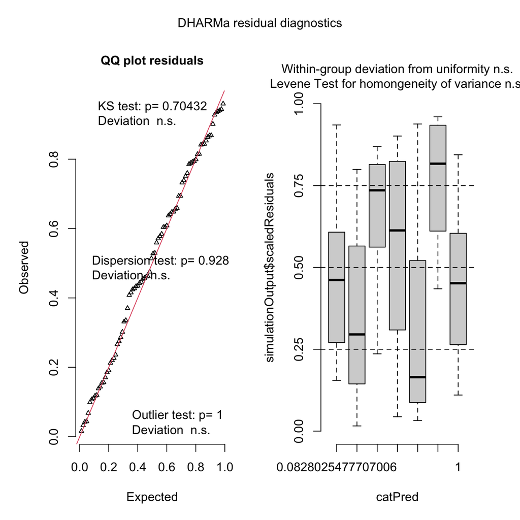

```
## Object of Class DHARMa with simulated residuals based on 250 simulations with refit = FALSE . See ?DHARMa::simulateResiduals for help.
##
## Scaled residual values: 0.3702523 0.7993836 0.1177944 0.7888279 0.185211 0.2205086 0.01590707 0.0988466 0.5714187 0.559334 0.454612 0.1705611 0.7941567 0.8536228 0.8637196 0.156507 0.6417282 0.9013027 0.2865024 0.6592493 ...
```

```r
simulateResiduals(mod4, plot = T, quantreg=T)
```

Very close observed and predicted values

```r
f1 <- plot(ggpredict(mod4, "total_rain"))
```

[output not shown]

[output not shown]

```r
f2 <- plot(ggpredict(mod4 , "rain_duration"))
```

[output not shown]

[output not shown]

```r
f3 <- plot(ggpredict(mod4, "wind_speed"))
```

[output not shown]

[output not shown]

```r
fig_5 <- grid.arrange(f1, f2, f3)
```

[output not shown]

[output not shown]

```r
ggsave(
   here("man", "figures/fig_5.png"),
   plot = fig_5,
   width = 9,
   height = 9,
   units = "in",
   dpi = 600
)
```

[output not shown]